# Love vs extraterrestials

Graciela Orozco

Spring 2020

# A question of Belief

Your data is in the dataframe called “mydata” examine it in the environment tab  
do a variable analysis on the 3 Questions and then upload the appropriate Rmd template for this job.  
Also create an empty github repository called “Belief” and make it the remote repository for  
this assignment. For each question supply graphical evidence, numerical summaries, an inferential test, and a conclusion. When finished push your rmd file, your project file, and your knitted html file to your github repo. Finally turn in to Canvas the link to your github repo.

# Your First Question

### Do people who believe in Love at First sight also tend to believe in Life on other planets?

$H_0$ There is no relation between people who belive in love at first sight and those who belive in life on other planets.  
$H_A$ There is a correlation between people who belive in love at first sight and those who belive in life in other planets. Graphic Display

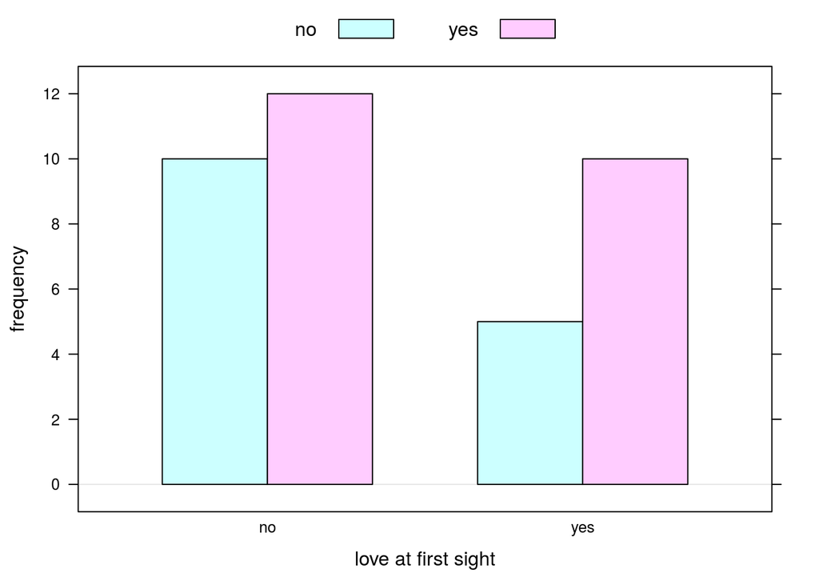

```r
barchartGC(~love_first + extra_life,data=mydata, xlab='love at first sight')
```

People who believe in love at first sight also tend believe life on other planets.

Numerical Summary

```r
table1 <- xtabs(~love_first + extra_life, data=mydata)
rowPerc(table1)
```

```
##           extra_life
## love_first     no    yes  Total
##        no   45.45  54.55 100.00
##        yes  33.33  66.67 100.00
```

```r
colPerc(table1)
```

```
##           extra_life
## love_first     no    yes
##      no     66.67  54.55
##      yes    33.33  45.45
##      Total 100.00 100.00
```

There is not much of a difference between people who do believe in love at first sight and those who belive in life on other planets.

Inference

```r
chisq.test(table1)
```

```
##
##  Pearson's Chi-squared test with Yates' continuity correction
##
## data:  table1
## X-squared = 0.15705, df = 1, p-value = 0.6919
```

```r
chisqtestGC(table1)
```

```
## Pearson's Chi-squared test with Yates' continuity correction
##
## Observed Counts:
##           extra_life
## love_first no yes
##        no  10  12
##        yes  5  10
##
## Counts Expected by Null:
##           extra_life
## love_first   no   yes
##        no  8.92 13.08
##        yes 6.08  8.92
##
## Contributions to the chi-square statistic:
##           extra_life
## love_first   no  yes
##        no  0.13 0.09
##        yes 0.19 0.13
##
##
## Chi-Square Statistic = 0.1571
## Degrees of Freedom of the table = 1
## P-Value = 0.6919
```

```r
fisher.test(table1)
```

```
##
##  Fisher's Exact Test for Count Data
##
## data:  table1
## p-value = 0.5144
## alternative hypothesis: true odds ratio is not equal to 1
## 95 percent confidence interval:
##  0.3559477 8.3319485
## sample estimates:
## odds ratio
##   1.643815
```

We fail to reject the null hypothesis. There is no evidence to support the contention of the relationship between love at first sight and extraterrestrial life. The p-value is bigger than 0.05.

# Your second Question

### Is there a difference between boys and girls with respect to belief in life on other planets?

$H_0$ there is no difference between boys and girls with respect to belief in life on other planets  
$H_A$ there is a difference between boys and girls with respect to belief in life on other planets

Graphical Display

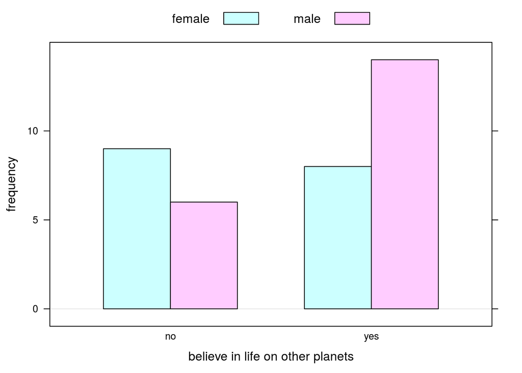

```r
barchartGC(~extra_life + sex,data=mydata, xlab= 'believe in life on other planets')
```

Numerical Summary

```r
table1 <- xtabs(~extra_life + sex, data=mydata)
rowPerc(table1)
```

```
##           sex
## extra_life female   male  Total
##        no   60.00  40.00 100.00
##        yes  36.36  63.64 100.00
```

```r
colPerc(table1)
```

```
##           sex
## extra_life female male
##      no     52.94   30
##      yes    47.06   70
##      Total 100.00  100
```

The summary shows a big difference between sex and their belief in life in other planets.

Inference

```r
chisq.test(table1)
```

```
##
##  Pearson's Chi-squared test with Yates' continuity correction
##
## data:  table1
## X-squared = 1.1675, df = 1, p-value = 0.2799
```

```r
chisqtestGC(table1)
```

```
## Pearson's Chi-squared test with Yates' continuity correction
##
## Observed Counts:
##           sex
## extra_life female male
##        no       9    6
##        yes      8   14
##
## Counts Expected by Null:
##           sex
## extra_life female  male
##        no    6.89  8.11
##        yes  10.11 11.89
##
## Contributions to the chi-square statistic:
##           sex
## extra_life female male
##        no    0.64 0.55
##        yes   0.44 0.37
##
##
## Chi-Square Statistic = 1.1675
## Degrees of Freedom of the table = 1
## P-Value = 0.2799
```

```r
fisher.test(table1)
```

```
##
##  Fisher's Exact Test for Count Data
##
## data:  table1
## p-value = 0.1931
## alternative hypothesis: true odds ratio is not equal to 1
## 95 percent confidence interval:
##   0.5642317 12.5617008
## sample estimates:
## odds ratio
##   2.554567
```

# Your last Question

### Is there a difference between boys and girls with respect to belief in love at First sight?

$H_0$ there is no relation between boys and girls with respect to belief in love at first sight  
$H_A$ there is relation between boys and girls with respect to belief in love at first sight

Graphical Display

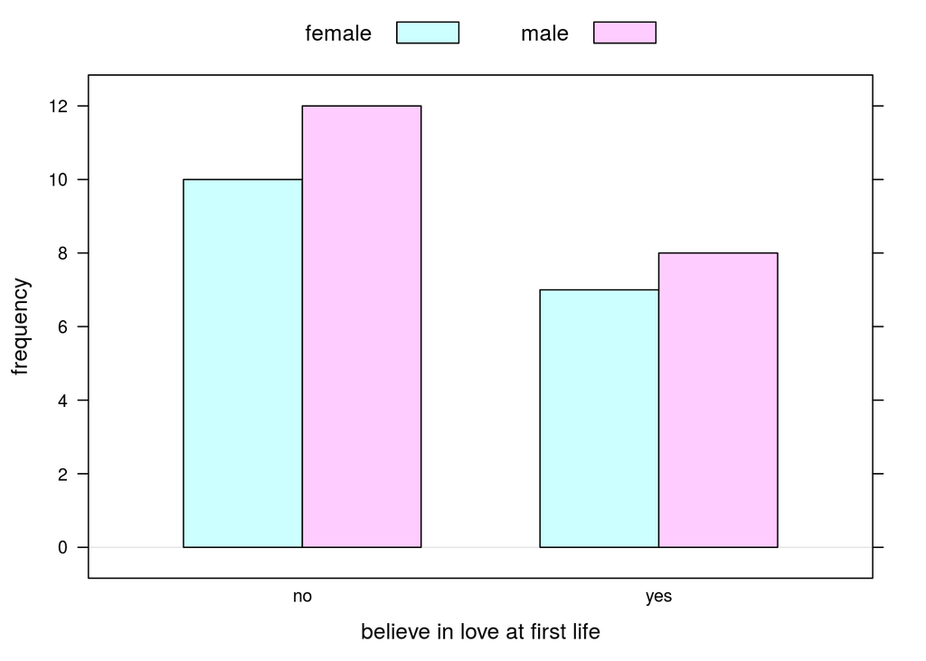

```r
barchartGC(~love_first + sex,data=mydata, xlab= 'believe in love at first life')
```

Numerical Display

```r
table1 <- xtabs(~love_first + sex, data=mydata)
rowPerc(table1)
```

```
##           sex
## love_first female   male  Total
##        no   45.45  54.55 100.00
##        yes  46.67  53.33 100.00
```

```r
colPerc(table1)
```

```
##           sex
## love_first female male
##      no     58.82   60
##      yes    41.18   40
##      Total 100.00  100
```

There is a big similarity between boys and girls and their belief in love at first class.

Inference

```r
chisq.test(table1)
```

```
##
##  Pearson's Chi-squared test with Yates' continuity correction
##
## data:  table1
## X-squared = 2.4167e-31, df = 1, p-value = 1
```

```r
chisqtestGC(table1)
```

```
## Pearson's Chi-squared test with Yates' continuity correction
##
## Observed Counts:
##           sex
## love_first female male
##        no      10   12
##        yes      7    8
##
## Counts Expected by Null:
##           sex
## love_first female  male
##        no   10.11 11.89
##        yes   6.89  8.11
##
## Contributions to the chi-square statistic:
##           sex
## love_first female male
##        no       0    0
##        yes      0    0
##
##
## Chi-Square Statistic = 0
## Degrees of Freedom of the table = 1
## P-Value = 1
```

```r
fisher.test(table1)
```

```
##
##  Fisher's Exact Test for Count Data
##
## data:  table1
## p-value = 1
## alternative hypothesis: true odds ratio is not equal to 1
## 95 percent confidence interval:
##  0.2112136 4.3386115
## sample estimates:
## odds ratio
##  0.9536685
```

We fail to reject the null hypothesis because the p-value is bigger than .05